# US Voting Patterns Analysis

Emma Bonanno, Emily Johansen, Katia Krotova

11/18/2021

## Research Question

Are there significant correlations between rural/suburban/urban characteristics, population density, race, income, and county-level voting patterns in the 2020 presidential election?

## Prior Research

Gimpel et. al (2020) find that urban–rural political party splits persist even after accounting for an array of individual-level characteristics, such as race, income and education. Hill et. al (2019) demonstrate that at the precinct level, local demographic changes and increasing diversity did not correlate to an increase in support for anti-immigration Republican candidates in the lead up to the 2016 presidential election.

## Data

Our sample population for this analysis is the full set of all counties across the United States (3,220 observations total).

The data included in the analysis is:

- People per square mile (American Community Survey 2017)
- Median income (American Community Survey 2017)
- Percentage of population identifying as White only and Black / African-American only (American Community Survey 2017)
- Percentage of population voting Republican in the 2020 presidential election (MIT Election Data and Science Lab, 2018)
- Urban-Rural County classification (National Center for Health Statistics 2013)

Load ACS Data

```r
acs <- get_acs(geography = "county",
                        year = 2017,
                        variables = c(total_pop = "B01003_001",
                                      med_inc = "B06011_001",
                                      Black = "B02001_003",
                                      white = "B02001_002"),
                        output = "wide",
                        geometry = TRUE)
areas <- counties() %>%
  st_set_geometry(NULL) %>%
  mutate(sq_miles = ALAND / 2589988.11) %>%
  select(GEOID, sq_miles)
```

Load suburban-rural classification

```r
CO_type <- read_xlsx(path = "data/NCHSURCodes2013.xlsx",
                      sheet = "NCHSURCodes2013") %>%
  mutate(GEOID = case_when(str_length(as.character(`FIPS code`)) == 5 ~
                            as.character(`FIPS code`),
                          str_length(as.character(`FIPS code`)) == 4 ~
                            paste("0", `FIPS code`, sep=""),
                          TRUE ~ "unknown")) %>%
  mutate(type = case_when(`2013 code` == 1 ~ "Large central metro",
                          `2013 code` == 2 ~ "Large fringe metro",
                          `2013 code` == 3 ~ "Medium metro",
                          `2013 code` == 4 ~ "Small metro",
                          `2013 code` == 5 ~ "Micropolitan",
                          `2013 code` == 6 ~ "Non-core",
                          TRUE ~ "unknown")) %>%
  select(GEOID, type)
```

Load election result (Democrat/Republican) data

```r
election <- read_csv('data/countypres_2000-2020.csv') %>%
  filter(year == 2020) %>%
  filter(party == "REPUBLICAN") %>%
  rename(GEOID = county_fips) %>%
  group_by(GEOID) %>%
  summarize(candidatevotes = sum(candidatevotes),
            totalvotes = first(totalvotes)) %>%
  mutate(pct_GOP = (candidatevotes / totalvotes)*100) %>%
  select(GEOID, pct_GOP)
```

```r
election <- election %>%
   mutate(GEOID = as.character(GEOID))
```

Join datasets:

```r
data <- left_join(acs, areas) %>%
  left_join(election) %>%
  left_join(CO_type) %>%
  mutate(pop_dens = total_popE / sq_miles) %>%
  mutate(black_pct = (BlackE / total_popE)*100) %>%
  mutate(white_pct = (whiteE / total_popE)*100) %>%
  select(GEOID, NAME, total_popE, pop_dens, med_incE, BlackE, black_pct, whiteE, white_pct, type, pct_GOP)

kable(head(data))
```

| GEOID | NAME | total_popE | pop_dens | med_incE | BlackE | black_pct | whiteE | white_pct | type | pct_GOP | geometry |
| --- | --- | --- | --- | --- | --- | --- | --- | --- | --- | --- | --- |
| 01005 | Barbour County, Alabama | 26201 | 29.60538 | 17184 | 12588 | 48.04397 | 12200 | 46.56311 | Non-core | NA | MULTIPOLYGON (((-85.74803 3… |
| 01023 | Choctaw County, Alabama | 13188 | 14.43730 | 18589 | 5583 | 42.33394 | 7456 | 56.53625 | Non-core | NA | MULTIPOLYGON (((-88.47323 3… |
| 01035 | Conecuh County, Alabama | 12649 | 14.87768 | 16708 | 5879 | 46.47798 | 6494 | 51.34003 | Non-core | NA | MULTIPOLYGON (((-87.4272 31… |
| 01051 | Elmore County, Alabama | 80989 | 130.95557 | 27234 | 17338 | 21.40785 | 60877 | 75.16700 | Medium metro | NA | MULTIPOLYGON (((-86.41333 3… |
| 01065 | Hale County, Alabama | 14995 | 23.28464 | 18573 | 8802 | 58.69957 | 5928 | 39.53318 | Small metro | NA | MULTIPOLYGON (((-87.87046 3… |
| 01109 | Pike County, Alabama | 33287 | 49.52923 | 20362 | 12648 | 37.99682 | 18995 | 57.06432 | Micropolitan | NA | MULTIPOLYGON (((-86.19941 3… |

# Descriptive Statistics

## Continuous Variables

The continuous variable used in this research are population density, median income, percentage of population identifying as White-only, percentage of population identifying as Black or African American-only, and percentage of a county’s population that voted Republican in the 2020 presidential election.

For each continuous variable, calculate:

1. The sample mean
2. The 95-percent confidence interval for the population mean
3. The sample standard deviation
4. The interquartile range
5. An illustration (e.g. a histogram) and description of the distribution.

### Calculations

```r
medinc_t_test <- t.test(data$med_incE)
dens_t_test <- t.test(data$pop_dens)
black_t_test <- t.test(data$black_pct)
white_t_test <- t.test(data$white_pct)
GOP_t_test <- t.test(data$pct_GOP)
```

```r
medinc_quartiles <- quantile(data$med_incE, na.rm = TRUE)
dens_quartiles <- quantile(data$pop_dens, na.rm = TRUE)
black_quartiles <- quantile(data$black_pct, na.rm = TRUE)
white_quartiles <- quantile(data$white_pct, na.rm = TRUE)
GOP_quartiles <- quantile(data$pct_GOP, na.rm = TRUE)
```

```r
medinc_st_dev <- sd(data$med_incE, na.rm = TRUE)
dens_st_dev <- sd(data$pop_dens, na.rm = TRUE)
black_st_dev <- sd(data$black_pct, na.rm = TRUE)
white_st_dev <- sd(data$white_pct, na.rm = TRUE)
GOP_st_dev <- sd(data$pct_GOP, na.rm = TRUE)
```

```r
medinc_hist <- ggplot(data) +
  geom_histogram(aes(x = med_incE),
                 bins = 30)
dens_hist <- ggplot(data) +
  geom_histogram(aes(x = pop_dens),
                 bins = 30) +
  scale_x_continuous(trans = "log")
black_hist <- ggplot(data) +
  geom_histogram(aes(x = black_pct),
                 bins = 30) +
   scale_x_continuous(trans = "log")
white_hist <- ggplot(data) +
  geom_histogram(aes(x = white_pct),
                 bins = 30)+
  scale_x_continuous(trans = "log")

GOP_hist <- ggplot(data) +
  geom_histogram(aes(x = pct_GOP),
                 bins = 30) +
  scale_x_continuous(trans = "log")
```

### Displaying Results

```r
medinc_t_test
```

```
##
##  One Sample t-test
##
## data:  data$med_incE
## t = 264.54, df = 3141, p-value < 2.2e-16
## alternative hypothesis: true mean is not equal to 0
## 95 percent confidence interval:
##  25509.27 25890.23
## sample estimates:
## mean of x
##  25699.75
```

```r
medinc_quartiles
```

```
##       0%      25%      50%      75%     100%
##  7102.00 22008.25 25183.50 28573.50 64686.00
```

```r
medinc_st_dev
```

```
## [1] 5445.518
```

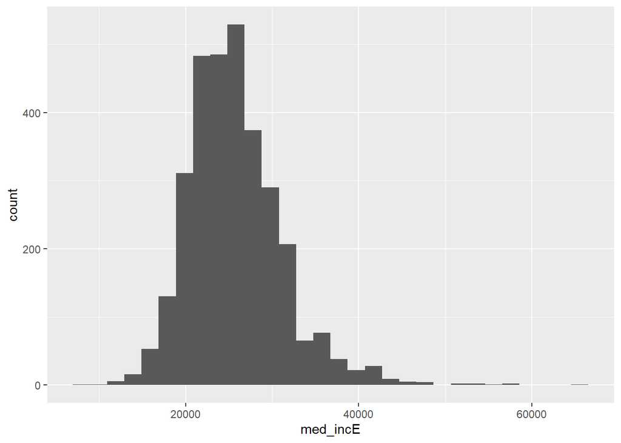

```r
medinc_hist
```

```r
cont_summary <- tibble(
  Variable = c("Median income",
               "Population density (people per square mile)",
               "Percentage of population identifying as Black or African-American only",
               "Percentage of population identifying as White only",
               "Percent who voted Republican"),
  `Sample mean` = c(medinc_t_test$estimate,
                    dens_t_test$estimate,
                    white_t_test$estimate,
                    black_t_test$estimate,
                    GOP_t_test$estimate),
  `Population mean (95% confidence) - low` =
    c(medinc_t_test$conf.int[1],
      dens_t_test$conf.int[1],
       white_t_test$conf.int[1],
      black_t_test$conf.int[1],
      GOP_t_test$conf.int[1]),
  `Population mean (95% confidence) - high` =
    c(medinc_t_test$conf.int[2],
      dens_t_test$conf.int[2],
      white_t_test$conf.int[2],
      black_t_test$conf.int[2],
      GOP_t_test$conf.int[2]),
  Median = c(medinc_quartiles[3],
             dens_quartiles[3],
             white_quartiles[3],
             black_quartiles[3],
             GOP_quartiles[3]),
  `Interquartile range` = c(medinc_quartiles[4] - medinc_quartiles[2],
                            dens_quartiles[4] - dens_quartiles[2],
                            white_quartiles[4] - white_quartiles[2],
                            black_quartiles[4] - black_quartiles[2],
                            GOP_quartiles[4] - GOP_quartiles[2]),
  `Standard deviation` = c(medinc_st_dev,
                          dens_st_dev,
                          white_st_dev,
                          black_st_dev,
                          GOP_st_dev))

kable(cont_summary, digits = 0)
```

[output not shown]

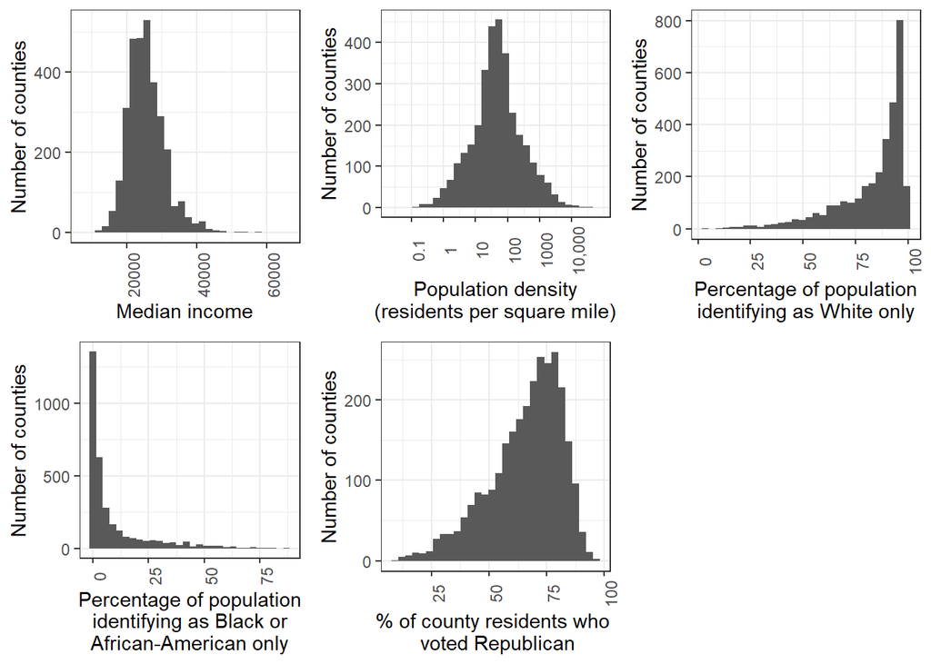

```r
pretty_medinc_hist <- medinc_hist +
  theme_bw() +
  scale_x_continuous(name = "Median income") +
  scale_y_continuous(name = "Number of counties") +
  theme(axis.text.x = element_text(angle = 90))


pretty_GOP_hist <- GOP_hist +
  theme_bw() +
  scale_x_continuous(name = "% of county residents who \n voted Republican") +
  scale_y_continuous(name = "Number of counties") +
  theme(axis.text.x = element_text(angle = 90))

pretty_dens_hist <- dens_hist +
  theme_bw() +
  scale_x_continuous(name = "Population density\n(residents per square mile)",
                     trans = "log",
                     breaks = c(0.1, 1, 10, 100, 1000, 10000),
                     labels = c("0.1", "1", "10", "100", "1000", "10,000")) +
  scale_y_continuous(name = "Number of counties") +
  theme(axis.text.x = element_text(angle = 90))

pretty_white_hist = white_hist +
  theme_bw() +
  scale_x_continuous(name = "Percentage of population\nidentifying as White only") +
  scale_y_continuous(name = "Number of counties") +
  theme(axis.text.x = element_text(angle = 90))

pretty_black_hist = black_hist +
  theme_bw() +
  scale_x_continuous(name = "Percentage of population\nidentifying as Black or\nAfrican-American only") +
  scale_y_continuous(name = "Number of counties") +
  theme(axis.text.x = element_text(angle = 90))

grid.arrange(pretty_medinc_hist, pretty_dens_hist, pretty_white_hist, pretty_black_hist, pretty_GOP_hist,
             ncol = 3)
```

## Categorical Variables

The categorical variable used in this analysis is:

- The county type (non-core, micropolitan, metropolitan, etc), based on the NCHS classification.

### Calculations

```r
pct_large_metro <- t.test(data$type == "Large central metro")
pct_fringe_metro <- t.test(data$type == "Large fringe metro")
pct_med_metro <- t.test(data$type == "Medium metro")
pct_small_metro <- t.test(data$type == "Small metro")
pct_micro <- t.test(data$type == "Micropolitan")
pct_rural <- t.test(data$type == "Non-core")
```

```r
cat_summary_type <- tibble(`County type` =
                              c("Large central metro",
                                "Large fringe metro",
                                "Medium metro",
                                "Small metro",
                                "Micropolitan",
                                "Non-core"),
                            `Sample proportion` =
                              c(pct_large_metro$estimate * 100,
                                pct_fringe_metro$estimate * 100,
                                pct_med_metro$estimate * 100,
                                pct_small_metro$estimate * 100,
                                pct_micro$estimate * 100,
                                pct_rural$estimate * 100),
                            `95-percent confidence - low` =
                              c(pct_large_metro$conf.int[1] * 100,
                                pct_fringe_metro$conf.int[1] * 100,
                                pct_med_metro$conf.int[1] * 100,
                                pct_small_metro$conf.int[1] * 100,
                                pct_micro$conf.int[1] * 100,
                                pct_rural$conf.int[1] * 100),
                            `95-percent confidence - high` =
                              c(pct_large_metro$conf.int[2] * 100,
                                pct_fringe_metro$conf.int[2] * 100,
                                pct_med_metro$conf.int[2] * 100,
                                pct_small_metro$conf.int[2] * 100,
                                pct_micro$conf.int[2] * 100,
                                pct_rural$conf.int[2] * 100))
kable(cat_summary_type, digits = 0)
```

| County type | Sample proportion | 95-percent confidence - low | 95-percent confidence - high |
| --- | --- | --- | --- |
| Large central metro | 2 | 2 | 3 |
| Large fringe metro | 12 | 11 | 13 |
| Medium metro | 12 | 11 | 13 |
| Small metro | 11 | 10 | 13 |
| Micropolitan | 20 | 19 | 22 |
| Non-core | 42 | 41 | 44 |

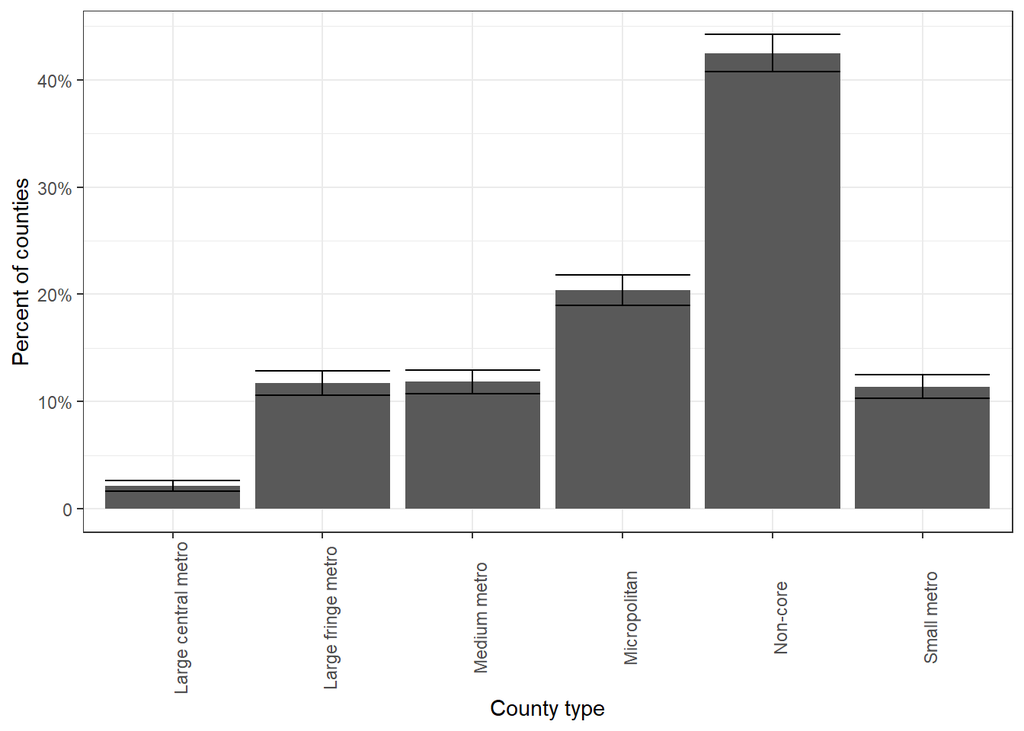

```r
ggplot(cat_summary_type) +
  geom_bar(aes(x = `County type`,
               y = `Sample proportion`),
           stat = "identity") +
  geom_errorbar(aes(x = `County type`,
               y = `Sample proportion`,
               ymin = `95-percent confidence - low`,
               ymax = `95-percent confidence - high`),
           stat = "identity") +
  scale_y_continuous(name = "Percent of counties",
                     breaks = c(0, 10, 20, 30, 40),
                     labels = c("0", "10%", "20%", "30%", "40%")) +
  theme_bw() +
  theme(axis.text.x = element_text(angle = 90))
```

# Bivariate Regression on Continuous Variables

## Population Density

```r
cor.test(~ pct_GOP + pop_dens, data = data)
```

```
##
##  Pearson's product-moment correlation
##
## data:  pct_GOP and pop_dens
## t = -14.355, df = 2821, p-value < 2.2e-16
## alternative hypothesis: true correlation is not equal to 0
## 95 percent confidence interval:
##  -0.2949641 -0.2261975
## sample estimates:
##        cor
## -0.2609117
```

```r
dens_model <- lm(pct_GOP ~ pop_dens, data = data)

summary(dens_model)
```

```
##
## Call:
## lm(formula = pct_GOP ~ pop_dens, data = data)
##
## Residuals:
##     Min      1Q  Median      3Q     Max
## -53.457  -8.987   2.774  11.502 104.735
##
## Coefficients:
##               Estimate Std. Error t value Pr(>|t|)
## (Intercept) 66.2694448  0.2869657  230.93   <2e-16 ***
## pop_dens    -0.0021766  0.0001516  -14.36   <2e-16 ***
## ---
## Signif. codes:  0 '***' 0.001 '**' 0.01 '*' 0.05 '.' 0.1 ' ' 1
##
## Residual standard error: 15.09 on 2821 degrees of freedom
##   (397 observations deleted due to missingness)
## Multiple R-squared:  0.06807,    Adjusted R-squared:  0.06774
## F-statistic: 206.1 on 1 and 2821 DF,  p-value: < 2.2e-16
```

The 95-percent confidence interval for the correlation does not include zero, and the correlation coefficient is negative. This means we can say with 95-percent confidence that higher population density within a county is associated with a lower percentage of Republican voters.

## Median Income

```r
cor.test(~ pct_GOP + med_incE, data = data)
```

```
##
##  Pearson's product-moment correlation
##
## data:  pct_GOP and med_incE
## t = -10.742, df = 2821, p-value < 2.2e-16
## alternative hypothesis: true correlation is not equal to 0
## 95 percent confidence interval:
##  -0.2334212 -0.1625339
## sample estimates:
##        cor
## -0.1982367
```

```r
inc_model <- lm(pct_GOP ~ med_incE, data = data)

summary(inc_model)
```

```
##
## Call:
## lm(formula = pct_GOP ~ med_incE, data = data)
##
## Residuals:
##     Min      1Q  Median      3Q     Max
## -58.478  -8.732   3.230  10.997  38.988
##
## Coefficients:
##               Estimate Std. Error t value Pr(>|t|)
## (Intercept)  8.078e+01  1.435e+00   56.29   <2e-16 ***
## med_incE    -5.863e-04  5.458e-05  -10.74   <2e-16 ***
## ---
## Signif. codes:  0 '***' 0.001 '**' 0.01 '*' 0.05 '.' 0.1 ' ' 1
##
## Residual standard error: 15.32 on 2821 degrees of freedom
##   (397 observations deleted due to missingness)
## Multiple R-squared:  0.0393, Adjusted R-squared:  0.03896
## F-statistic: 115.4 on 1 and 2821 DF,  p-value: < 2.2e-16
```

The 95-percent confidence interval for the correlation does not include zero, and the correlation coefficient is negative. This means we can say with 95-percent confidence that higher median income within a county is associated with a lower percentage of Republican voters.

## Percentage of population identifying as white only

```r
cor.test(~ pct_GOP + white_pct, data = data)
```

```
##
##  Pearson's product-moment correlation
##
## data:  pct_GOP and white_pct
## t = 34.6, df = 2821, p-value < 2.2e-16
## alternative hypothesis: true correlation is not equal to 0
## 95 percent confidence interval:
##  0.5194042 0.5712255
## sample estimates:
##       cor
## 0.5458366
```

```r
inc_model <- lm(pct_GOP ~ white_pct, data = data)

summary(inc_model)
```

```
##
## Call:
## lm(formula = pct_GOP ~ white_pct, data = data)
##
## Residuals:
##     Min      1Q  Median      3Q     Max
## -48.440  -7.505   2.028   9.440  38.148
##
## Coefficients:
##             Estimate Std. Error t value Pr(>|t|)
## (Intercept) 20.95167    1.31589   15.92   <2e-16 ***
## white_pct    0.53130    0.01536   34.60   <2e-16 ***
## ---
## Signif. codes:  0 '***' 0.001 '**' 0.01 '*' 0.05 '.' 0.1 ' ' 1
##
## Residual standard error: 13.1 on 2821 degrees of freedom
##   (397 observations deleted due to missingness)
## Multiple R-squared:  0.2979, Adjusted R-squared:  0.2977
## F-statistic:  1197 on 1 and 2821 DF,  p-value: < 2.2e-16
```

The 95-percent confidence interval for the correlation does not include zero, and the correlation coefficient is positive. This means we can say with 95-percent confidence that a higher percentage of white-only identifying people within a county is associated with a higher percentage of Republican voters.

## Percent of population identifying as Black / African-American only

```r
cor.test(~ pct_GOP + black_pct, data = data)
```

```
##
##  Pearson's product-moment correlation
##
## data:  pct_GOP and black_pct
## t = -27.379, df = 2821, p-value < 2.2e-16
## alternative hypothesis: true correlation is not equal to 0
## 95 percent confidence interval:
##  -0.4868475 -0.4285373
## sample estimates:
##        cor
## -0.4581852
```

```r
inc_model <- lm(pct_GOP ~ black_pct, data = data)

summary(inc_model)
```

```
##
## Call:
## lm(formula = pct_GOP ~ black_pct, data = data)
##
## Residuals:
##     Min      1Q  Median      3Q     Max
## -52.393  -7.611   2.895  10.117  26.129
##
## Coefficients:
##             Estimate Std. Error t value Pr(>|t|)
## (Intercept) 70.12488    0.30785  227.79   <2e-16 ***
## black_pct   -0.50714    0.01852  -27.38   <2e-16 ***
## ---
## Signif. codes:  0 '***' 0.001 '**' 0.01 '*' 0.05 '.' 0.1 ' ' 1
##
## Residual standard error: 13.89 on 2821 degrees of freedom
##   (397 observations deleted due to missingness)
## Multiple R-squared:  0.2099, Adjusted R-squared:  0.2097
## F-statistic: 749.6 on 1 and 2821 DF,  p-value: < 2.2e-16
```

The 95-percent confidence interval for the correlation does not include zero, and the correlation coefficient is negative. This means we can say with 95-percent confidence that a higher percentage of Black-only identifying people within a county is associated with a lower percentage of Republican voters.

# Bivariate Regression on Categorical Variables

## Urban-Rural County classification

Is there a relationship between voting patterns and the urban/rural makeup of a county?

```r
data <- data %>%
  mutate(type = as.factor(type)) %>%
  mutate(type = relevel(type, "Large central metro"))
type_model <- lm(pct_GOP ~ type, data)
summary(type_model)
```

```
##
## Call:
## lm(formula = pct_GOP ~ type, data = data)
##
## Residuals:
##     Min      1Q  Median      3Q     Max
## -58.500  -7.996   2.663   9.833  33.251
##
## Coefficients:
##                        Estimate Std. Error t value Pr(>|t|)
## (Intercept)              32.512      1.873   17.36   <2e-16 ***
## typeLarge fringe metro   25.342      2.018   12.56   <2e-16 ***
## typeMedium metro         27.313      2.024   13.50   <2e-16 ***
## typeMicropolitan         33.008      1.958   16.85   <2e-16 ***
## typeNon-core             39.576      1.915   20.66   <2e-16 ***
## typeSmall metro          29.587      2.028   14.59   <2e-16 ***
## ---
## Signif. codes:  0 '***' 0.001 '**' 0.01 '*' 0.05 '.' 0.1 ' ' 1
##
## Residual standard error: 13.89 on 2817 degrees of freedom
##   (397 observations deleted due to missingness)
## Multiple R-squared:  0.2114, Adjusted R-squared:   0.21
## F-statistic: 151.1 on 5 and 2817 DF,  p-value: < 2.2e-16
```

Since the coefficient for each is positive (represented in the first “Estimate Std” column), there is a positive relationship between each of these types and GOP voting. Since the coefficients are higher for micropolitan and non-core cities, we can infer that GOP voting is generally higher in these types of cities than in the others which have lower coefficients.

# Multivariate Regression

```r
full_model <- lm(pct_GOP ~ med_incE + pop_dens + white_pct + black_pct + type, data)

summary(full_model)
```

```
##
## Call:
## lm(formula = pct_GOP ~ med_incE + pop_dens + white_pct + black_pct +
##     type, data = data)
##
## Residuals:
##     Min      1Q  Median      3Q     Max
## -49.153  -6.179   1.321   7.827  32.803
##
## Coefficients:
##                          Estimate Std. Error t value Pr(>|t|)
## (Intercept)             2.766e+01  3.226e+00   8.573  < 2e-16 ***
## med_incE               -5.898e-04  4.937e-05 -11.947  < 2e-16 ***
## pop_dens               -5.445e-04  1.317e-04  -4.134 3.67e-05 ***
## white_pct               4.555e-01  2.553e-02  17.842  < 2e-16 ***
## black_pct              -6.868e-02  2.906e-02  -2.363   0.0182 *
## typeLarge fringe metro  1.272e+01  1.843e+00   6.901 6.38e-12 ***
## typeMedium metro        1.161e+01  1.874e+00   6.194 6.73e-10 ***
## typeMicropolitan        1.421e+01  1.860e+00   7.636 3.04e-14 ***
## typeNon-core            1.985e+01  1.840e+00  10.791  < 2e-16 ***
## typeSmall metro         1.229e+01  1.891e+00   6.496 9.70e-11 ***
## ---
## Signif. codes:  0 '***' 0.001 '**' 0.01 '*' 0.05 '.' 0.1 ' ' 1
##
## Residual standard error: 11.53 on 2813 degrees of freedom
##   (397 observations deleted due to missingness)
## Multiple R-squared:  0.4569, Adjusted R-squared:  0.4551
## F-statistic: 262.9 on 9 and 2813 DF,  p-value: < 2.2e-16
```

## Results

Since all of the variables have a p-value of less than 0.05, they are all significant at a 95% confidence interval.

**Population Density:** A one person/sq. mi. increase in population density corresponded with a -0.0021766% change in GOP voters. In the multivariate regression, once we controlled for other factors, a one person increase in population density was associated with a decrease of 0.00055% in GOP voters. As a result, our analysis suggested that population density had a much weaker effect on the percentage of voters in a county who voted for the GOP when all other variables were held constant.

**Black Pct:** In the bivariate regression a one percent increase in the county’s Black population was associated with a decrease in the percent of GOP voters of 0.50714%. If we control for all other variables, our multivariate regression showed that a one percent increase in Black population was associated with a decrease in the GOP percent of 0.068688%.

**County Type:** Since most of the county types had similar coefficients, they tend to have a similar effect on GOP voting outcomes. Since population density may account for some of the differences between county types, it may be a better predictor. Still, non-core (rural) and micropolitan counties saw the highest increase in the share of GOP votes.

Overall, our model explains about 45% of the variation in county-level voting patterns.

# Transformations & Scaling

## Mean Centering

We chose to mean center the population density and median income variables. By doing so, we are able to predict how variation in density and income away from average impacts the percent of GOP votes.

```r
centered_data <- data %>%
  mutate(pop_dens = pop_dens - mean(pop_dens, na.rm=TRUE),
         med_incE = med_incE - mean(med_incE, na.rm=TRUE))

centered_model <- lm(pct_GOP ~ med_incE + pop_dens + white_pct + black_pct + type, centered_data)

export_summs(full_model, centered_model,
             error_format = "(p = {p.value})",
             error_pos = "same",
             model.names = c("Initial", "Centered"),
             coeffs = "coeff_names")
```

|  | Initial | Centered |
| --- | --- | --- |
| (Intercept) | 27.66 *** (p = 0.00) | 12.34 *** (p = 0.00) |
| med_incE | -0.00 *** (p = 0.00) | -0.00 *** (p = 0.00) |
| pop_dens | -0.00 *** (p = 0.00) | -0.00 *** (p = 0.00) |
| white_pct | 0.46 *** (p = 0.00) | 0.46 *** (p = 0.00) |
| black_pct | -0.07 * (p = 0.02) | -0.07 * (p = 0.02) |
| typeLarge fringe metro | 12.72 *** (p = 0.00) | 12.72 *** (p = 0.00) |
| typeMedium metro | 11.61 *** (p = 0.00) | 11.61 *** (p = 0.00) |
| typeMicropolitan | 14.21 *** (p = 0.00) | 14.21 *** (p = 0.00) |
| typeNon-core | 19.85 *** (p = 0.00) | 19.85 *** (p = 0.00) |
| typeSmall metro | 12.29 *** (p = 0.00) | 12.29 *** (p = 0.00) |
| N | 2823 | 2823 |
| R2 | 0.46 | 0.46 |
| *** p < 0.001; ** p < 0.01; * p < 0.05. |  |  |

By mean centering the data, the R-squared value remained constant with our initial model, but the intercept shifted. In this case, the mean-centered intercept represents the percentage of GOP votes in a hypothetical Large Central Metro county where population density and median income are average and there are zero white or Black residents.

```r
coeff_names <- c("Constant" = "(Intercept)",
                 "Median income" = "med_incE",
                 "Population density (people per square mile)" = "pop_dens",
                 "White Population (%)" = "white_pct",
                 "Black Population (%)" = "black_pct",
                 "Large fringe metro" = "typeLarge fringe metro",
                 "Medium metro" = "typeMedium metro",
                 "Small metro" = "typeSmall metro",
                 "Micropolitan" = "typeMicropolitan",
                 "Rural" = "typeNon-core")

export_summs(full_model, centered_model,
             error_format = "(p = {p.value})",
             error_pos = "same",
             model.names = c("Initial", "Centered"),
             coefs = coeff_names)
```

|  | Initial | Centered |
| --- | --- | --- |
| Constant | 27.66 *** (p = 0.00) | 12.34 *** (p = 0.00) |
| Median income | -0.00 *** (p = 0.00) | -0.00 *** (p = 0.00) |
| Population density (people per square mile) | -0.00 *** (p = 0.00) | -0.00 *** (p = 0.00) |
| White Population (%) | 0.46 *** (p = 0.00) | 0.46 *** (p = 0.00) |
| Black Population (%) | -0.07 * (p = 0.02) | -0.07 * (p = 0.02) |
| Large fringe metro | 12.72 *** (p = 0.00) | 12.72 *** (p = 0.00) |
| Medium metro | 11.61 *** (p = 0.00) | 11.61 *** (p = 0.00) |
| Small metro | 12.29 *** (p = 0.00) | 12.29 *** (p = 0.00) |
| Micropolitan | 14.21 *** (p = 0.00) | 14.21 *** (p = 0.00) |
| Rural | 19.85 *** (p = 0.00) | 19.85 *** (p = 0.00) |
| N | 2823 | 2823 |
| R2 | 0.46 | 0.46 |
| *** p < 0.001; ** p < 0.01; * p < 0.05. |  |  |

## Scaling

We chose to scale the population density and median income variables since the coefficients were extremely small in our initial model. Our initial model predicted the change in the percent GOP votes for a one dollar change in median income and a one person per square mile change in population density. Since the variables being rescaled have already been mean-centered, the new model will predict the change in GOP votes for a $1,000 change in median income over the average, and the change in GOP votes for a 100 person change in population density over the average.

```r
centered_data_scaled <- centered_data %>%
  mutate(med_incE = med_incE / 1000,
         pop_dens_100 = pop_dens / 100)

coeff_names_scaled <- c("Constant" = "(Intercept)",
                 "Median Income ($000s)" = "med_incE",
                 "Population density (100 people per square mile)" = "pop_dens_100",
                 "White Population" = "white_pct",
                 "Black Population" = "black_pct",
                 "Large fringe metro" = "typeLarge fringe metro",
                 "Medium metro" = "typeMedium metro",
                 "Small metro" = "typeSmall metro",
                 "Micropolitan" = "typeMicropolitan",
                 "Rural" = "typeNon-core")


centered_model_scaled <- lm(pct_GOP ~ med_incE + pop_dens_100 + white_pct + black_pct + type, centered_data_scaled)

export_summs(full_model, centered_model,centered_model_scaled,
             error_format = "(p = {p.value})",
             error_pos = "same",
             model.names = c("Initial",
                             "Centered",
                             "Centered\n(per 100 residents)"),
             coefs = coeff_names_scaled)
```

|  | Initial | Centered | Centered (per 100 residents) |
| --- | --- | --- | --- |
| Constant | 27.66 *** (p = 0.00) | 12.34 *** (p = 0.00) | 12.34 *** (p = 0.00) |
| Median Income ($000s) | -0.00 *** (p = 0.00) | -0.00 *** (p = 0.00) | -0.59 *** (p = 0.00) |
| Population density (100 people per square mile) |  |  | -0.05 *** (p = 0.00) |
| White Population | 0.46 *** (p = 0.00) | 0.46 *** (p = 0.00) | 0.46 *** (p = 0.00) |
| Black Population | -0.07 * (p = 0.02) | -0.07 * (p = 0.02) | -0.07 * (p = 0.02) |
| Large fringe metro | 12.72 *** (p = 0.00) | 12.72 *** (p = 0.00) | 12.72 *** (p = 0.00) |
| Medium metro | 11.61 *** (p = 0.00) | 11.61 *** (p = 0.00) | 11.61 *** (p = 0.00) |
| Small metro | 12.29 *** (p = 0.00) | 12.29 *** (p = 0.00) | 12.29 *** (p = 0.00) |
| Micropolitan | 14.21 *** (p = 0.00) | 14.21 *** (p = 0.00) | 14.21 *** (p = 0.00) |
| Rural | 19.85 *** (p = 0.00) | 19.85 *** (p = 0.00) | 19.85 *** (p = 0.00) |
| N | 2823 | 2823 | 2823 |
| R2 | 0.46 | 0.46 | 0.46 |
| *** p < 0.001; ** p < 0.01; * p < 0.05. |  |  |  |

By mean centering and scaling our model, we are able to produce more easily interpretable coefficients. Our centered and scaled model now predicts the effect on GOP votes as median income deviates from the average by 1,000 dollars, as well as for a change in population density of 100 people over the average.

In the initial and centered models, the coefficient for median income was extremely small (displayed as zero) because we were analyzing the change in GOP voting percentage when median income changes by only one dollar. In scaling the data, we were able to identify the change in GOP voting % when median income changes by 1,000. The output of the model was more meaningful in this case and returned a 0.59% decrease in GOP votes for a $1,000 increase in median income over the average.

Similarly, the coefficient for population density was also extremely small because we were analyzing the change in GOP votes when population density changes by only one person. In scaling the data, we were able to identify the change in GOP voting % when population density changes by 100 people per square mile. The model in this case returned a 0.05% decrease in percent GOP votes when population density increased by 100 over the average.

Since the R-squared value remained the same for all three models (equal to 0.46), our model fit did not change. This implies that 46% of change in GOP votes (%) can be attributed to these variables.

# Interactions

Controlling for median income, an increase in the percentage of Black identifying residents results in a decrease in Republican voters. Does the relationship between median income and percentage of Republican voters change depending on the racial makeup of a county?

```r
coeff_names_interaction <- c("Constant" = "(Intercept)",
                 "Median Income ($000s)" = "med_incE",
                 "Population density (100 people per square mile)" = "pop_dens_100",
                 "White Population" = "white_pct",
                 "Black Population" = "black_pct",
                 "Large fringe metro" = "typeLarge fringe metro",
                 "Medium metro" = "typeMedium metro",
                 "Small metro" = "typeSmall metro",
                 "Micropolitan" = "typeMicropolitan",
                 "Rural" = "typeNon-core")


interaction_model <- lm(pct_GOP ~ med_incE + pop_dens_100 + white_pct + black_pct + type + med_incE*black_pct, centered_data_scaled)

export_summs(centered_model_scaled, interaction_model,
             error_format = "(p = {p.value})",
             error_pos = "same",
             model.names = c("Centered\n(per 100 residents)",
                             "Interaction"))
```

|  | Centered (per 100 residents) | Interaction |
| --- | --- | --- |
| (Intercept) | 12.34 *** (p = 0.00) | 11.03 *** (p = 0.00) |
| med_incE | -0.59 *** (p = 0.00) | -0.64 *** (p = 0.00) |
| pop_dens_100 | -0.05 *** (p = 0.00) | -0.06 *** (p = 0.00) |
| white_pct | 0.46 *** (p = 0.00) | 0.46 *** (p = 0.00) |
| black_pct | -0.07 * (p = 0.02) | -0.03 (p = 0.29) |
| typeLarge fringe metro | 12.72 *** (p = 0.00) | 13.19 *** (p = 0.00) |
| typeMedium metro | 11.61 *** (p = 0.00) | 12.21 *** (p = 0.00) |
| typeMicropolitan | 14.21 *** (p = 0.00) | 15.00 *** (p = 0.00) |
| typeNon-core | 19.85 *** (p = 0.00) | 20.67 *** (p = 0.00) |
| typeSmall metro | 12.29 *** (p = 0.00) | 12.99 *** (p = 0.00) |
| med_incE:black_pct |  | 0.01 * (p = 0.03) |
| N | 2823 | 2823 |
| R2 | 0.46 | 0.46 |
| *** p < 0.001; ** p < 0.01; * p < 0.05. |  |  |

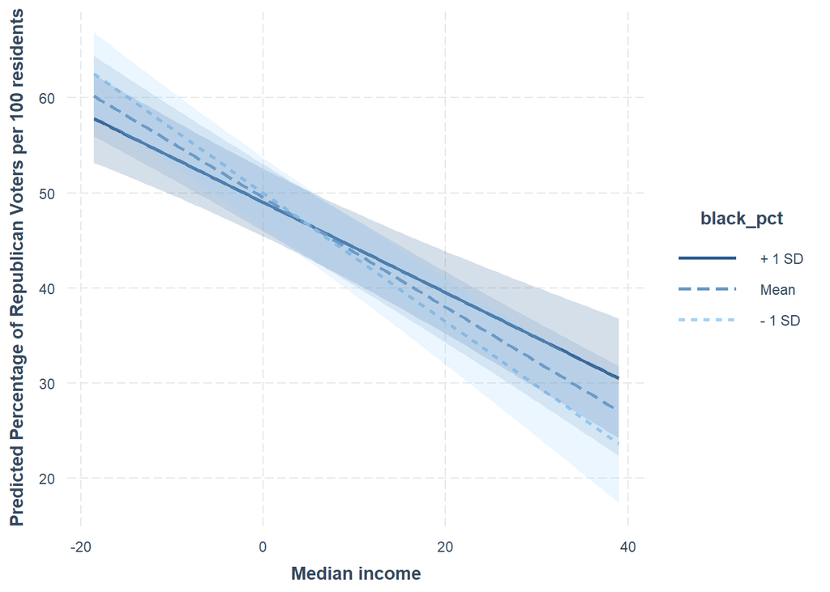

```r
interact_plot(interaction_model, pred = med_incE, modx = black_pct,
              interval = TRUE) +
  scale_x_continuous(name = "Median income") +
  scale_y_continuous(name = "Predicted Percentage of Republican Voters per 100 residents")
```

# References

Gimpel, J.G., N. Lovin, B. Moy, & A. Reeves (2020). “The Urban–Rural Gulf in American Political Behavior”. Political Behavior, 42, 1343-1368.

Hill, Seth J., Daniel J. Hopkins, Gregory A. Huber (2019). “Local demographic changes and US presidential voting, 2012 to 2016”. Proceedings of the National Academy of Arts and Sciences, December 10, 2019 116 (50) 25023-25028.